# Intro to R and Rstudio

# Getting Started: R Basics for Beginners

If you’ve used Python before, R will feel partially familiar — but there are some important differences. This section covers the essentials you need to get going. **If you’ve never programmed before, don’t worry** — everything is explained step by step.

## Using the R Console (the “REPL”)

The **console** is the panel (usually at the bottom of RStudio) where you type commands and R responds with results. Here’s what the prompts mean:

- **`>`** — R is ready and waiting for you to type something.
- **`+`** — R thinks your previous line was incomplete (e.g., you opened a bracket but didn’t close it). Either finish the expression or press **Escape** to cancel.
- **Tab** — Press this key to auto-complete variable names, function names, and file paths. Very handy!
- **Ctrl+Enter** (or **Cmd+Enter** on Mac) — Runs the current line (or highlighted code) from a script or R Markdown file.

## Key Differences: R vs Python

If you’ve used Python, here’s a quick comparison:

| Python | R | Example |
| --- | --- | --- |
| `obj.method(arg)` | `fun(obj, arg)` | R uses functions, not methods |
| `:` and indentation for blocks | `{ }` curly braces for blocks | `if (x > 0) { print("yes") }` |
| Indexing starts at **0** | Indexing starts at **1** | `x[1]` gets the *first* element in R |
| `[1, 2, 3]` | `c(1, 2, 3)` | `c()` stands for “combine” |
| `x.append("foo")` | `x <- c(x, "foo")` | R doesn’t modify in-place |
| `=` for assignment | `<-` for assignment | `x <- 5` (the arrow “points” to the variable) |

> **Why `<-` instead of `=`?** Both *technically* work in R, but `<-` is the convention and they actually have slightly different behaviour in some situations. Just use `<-` and you’ll be safe.

## How to Get Help

R has excellent built-in documentation:

- **`?topic`** or **`help("topic")`** — Opens the help page for any function or topic. Example: `?mean`
- **`example(fun)`** — Shows live examples of how a function is used. Try `example(plot)`!
- **`help(package = "foo")`** — Shows all the functions in a package.
- Don’t be scared by functions with 20+ arguments — usually only 2 or 3 are required. The rest have sensible defaults.

## Installing and Loading Packages

Packages are **add-on libraries** that extend R’s capabilities (like pip packages in Python):

- **Install:** `install.packages("packagename")` — downloads the package (you only need to do this once).
- **Load:** `library(packagename)` — makes the package available for your current session (you do this every time you restart R).
- Unlike Python, you don’t need to type `package.function()` — just call the function directly after loading the package. If two packages have functions with the same name, use `package::function()` to specify which one.

# Statistical Computing – Lab 1: R for Computational Statistics

## What This Lab Is About

In this module, **R isn’t just a calculator** — it’s a language for writing **statistical algorithms**. Throughout the course, you’ll use R for things like:

- **Likelihood-based inference** (estimating parameters from data)
- **Simulation studies** (generating fake data to test methods)
- **Numerical optimization** (finding the best-fitting model)
- **Mixture models and MCMC** (advanced modelling techniques)

This lab teaches you the **core R skills** that everything else builds on. Almost every concept here will come back in later weeks, so it’s worth getting comfortable now.

## 1. Reproducibility and Basic Computation

### Why `set.seed()`?

Statistical computing uses **random numbers** a lot (for simulations, sampling, etc.). But if your results change every time you run the code, nobody can reproduce your work! `set.seed()` fixes the random number generator to a specific starting point, so you get the **same “random” numbers every time**.

```r
set.seed(123)
```

### Basic vector operations

A **vector** is just a list of numbers. It’s the most fundamental data structure in R. Here we create one and compute some basic statistics:

```r
x <- c(1, 2, 3, 4, 5)
mean(x)
```

```
## [1] 3
```

```r
sum(x)
```

```
## [1] 15
```

```r
sd(x)
```

```
## [1] 1.581139
```

- **`mean(x)`** — the average: add up all the numbers and divide by how many there are.
- **`sum(x)`** — adds up all the numbers.
- **`sd(x)`** — the standard deviation: a measure of how spread out the numbers are.

### Computing the mean “by hand”

The sample mean is just $\bar{x} = \frac{\text{sum of all values}}{\text{number of values}}$. We can write that directly in R:

```r
sum(x) / length(x)
```

```
## [1] 3
```

This gives the same answer as `mean(x)`. Later in the module, we’ll see that *how* you compute things can matter when numbers are very large or very small (a topic called **numerical stability**).

### Your turn: Extreme numbers

What happens when we mix very large and very small numbers? Let’s find out. Below we create a vector with one huge number (10,000,000,000,000,000) and three tiny ones (1, 2, 3), then compute the mean three different ways:

- **Method 1:** R’s built-in `mean()`.
- **Method 2:** Manual `sum(x) / length(x)`.
- **Method 3:** A “compensated” approach that subtracts a reference value first to reduce rounding errors.

```r
x <- c(1e16, 1, 2, 3)

# Method 1: R's built-in mean
mean_builtin <- mean(x)

# Method 2: manual sum / length
mean_manual <- sum(x) / length(x)

# Method 3: compensated sum relative to first element
mean_compensated <- (sum(x - x[1]) + length(x) * x[1]) / length(x)

cat("Built-in mean:      ", mean_builtin, "\n")
```

```
## Built-in mean:       2.5e+15
```

```r
cat("Manual mean:        ", mean_manual, "\n")
```

```
## Manual mean:         2.5e+15
```

```r
cat("Compensated mean:   ", mean_compensated, "\n")
```

```
## Compensated mean:    2.5e+15
```

```r
cat("Difference (builtin - manual):", mean_builtin - mean_manual, "\n")
```

```
## Difference (builtin - manual): 0.5
```

```r
options(digits = 22)
cat("Built-in mean:      ", mean_builtin, "\n")
```

```
## Built-in mean:       2500000000000001.5
```

```r
cat("Manual mean:        ", mean_manual, "\n")
```

```
## Manual mean:         2500000000000001
```

```r
cat("Compensated mean:   ", mean_compensated, "\n")
```

```
## Compensated mean:    2500000000000001
```

```r
cat("Difference (builtin - manual):", mean_builtin - mean_manual, "\n")
```

```
## Difference (builtin - manual): 0.5
```

```r
options(digits = 7)  # reset to default
```

> **Takeaway:** Computers store numbers with limited precision (about 15–16 significant digits). When you mix very large and very small numbers, the small ones can get “lost” in the rounding. This is why numerical methods matter!

## 2. Vectors, Indexing, and Logical Operations

### What is a vector?

A **vector** is R’s most basic data structure — simply an ordered collection of values of the same type (all numbers, or all text, etc.). Almost everything in R operates on vectors.

```r
x <- c(10, 11, 12)
names(x) <- c("first", "second", "third")
```

Here we created a vector with three numbers and gave each one a **name**. Names are optional but make code more readable.

### Extracting elements (indexing)

You can pull out specific elements using square brackets `[ ]`:

```r
x[1:2]
```

```
##  first second
##     10     11
```

```r
x[x > 10]
```

```
## second  third
##     11     12
```

```r
x[c("first", "third")]
```

```
## first third
##    10    12
```

- **`x[1:2]`** — Gets elements 1 and 2 (remember: R counts from 1, not 0!).
- **`x[x > 10]`** — Gets only the elements greater than 10. This is called **logical indexing** — R checks each element, keeps the ones where the condition is `TRUE`, and drops the rest.
- **`x[c("first", "third")]`** — Gets elements by their names.

> **Logical indexing** is one of the most useful tricks in R. You’ll use it constantly for filtering data.

### Your turn: Working with random numbers

The function `rnorm(n)` generates `n` random numbers from a Normal (bell curve) distribution. If you’re unsure what a function does, type `?rnorm` in the console to see its help page.

```r
# Create a numeric vector of length 10 using rnorm()
set.seed(42)
v <- rnorm(10)
v
```

```
##  [1]  1.37095845 -0.56469817  0.36312841  0.63286260  0.40426832 -0.10612452
##  [7]  1.51152200 -0.09465904  2.01842371 -0.06271410
```

```r
# Extract only the positive values using logical indexing
v_positive <- v[v > 0]
v_positive
```

```
## [1] 1.3709584 0.3631284 0.6328626 0.4042683 1.5115220 2.0184237
```

```r
# Replace all negative values with 0
v_nonneg <- v
v_nonneg[v_nonneg < 0] <- 0
v_nonneg
```

```
##  [1] 1.3709584 0.0000000 0.3631284 0.6328626 0.4042683 0.0000000 1.5115220
##  [8] 0.0000000 2.0184237 0.0000000
```

## 3. From Vectors to Data Frames

### What is a data frame?

A **data frame** is R’s version of a spreadsheet — it stores data in rows and columns. Each column is a vector, and all columns must have the same number of rows. This is how you’ll store most datasets.

```r
students <- data.frame(
  name = c("Alice", "Bob", "Charlie", "Dana"),
  age = c(22, 23, 24, NA),
  grade = c("A", "B", "A", "B")
)

students
```

```
##      name age grade
## 1   Alice  22     A
## 2     Bob  23     B
## 3 Charlie  24     A
## 4    Dana  NA     B
```

```r
summary(students)
```

```
##      name                age          grade
##  Length:4           Min.   :22.0   Length:4
##  Class :character   1st Qu.:22.5   Class :character
##  Mode  :character   Median :23.0   Mode  :character
##                     Mean   :23.0
##                     3rd Qu.:23.5
##                     Max.   :24.0
##                     NA's   :1
```

### Dealing with missing values (`NA`)

In R, **`NA`** means “Not Available” — i.e., the value is missing. Dana’s age is `NA` above. If you try to compute the mean of a column with `NA`s, R will return `NA` (because it doesn’t know the missing value). To tell R “just ignore the missing ones”, use `na.rm = TRUE`:

```r
mean(students$age, na.rm = TRUE)
```

```
## [1] 23
```

> **`na.rm`** stands for “NA remove”. You’ll use this argument all the time.

### Adding new columns using a mapping

Sometimes you want to convert categories to numbers (e.g., grades to numeric scores). You can do this by creating a **named vector** that acts like a lookup table:

```r
# Add a new column converting grades to numeric values (A = 70, B = 60)
gmap <- c(A = 70, B = 60)
students$grade_numeric <- gmap[students$grade]
students
```

```
##      name age grade grade_numeric
## 1   Alice  22     A            70
## 2     Bob  23     B            60
## 3 Charlie  24     A            70
## 4    Dana  NA     B            60
```

**How this works:** `gmap` is a named vector where `A` maps to 70 and `B` maps to 60. When you write `gmap[students$grade]`, R looks up each student’s grade in the mapping and returns the corresponding number.

### Summarizing by group

The `aggregate()` function lets you compute a summary (like the mean) **separately for each group**:

```r
# Compute the average age for each grade
aggregate(age ~ grade, data = students, FUN = mean, na.rm = TRUE)
```

```
##   grade age
## 1     A  23
## 2     B  23
```

> **Reading the formula:** `age ~ grade` means “break `age` into groups defined by `grade`, and apply the function to each group.”

## 4. Some Probability

### Why do we care about probability in R?

Many things we’ll do later in this module — likelihood functions, simulations, mixture models, MCMC — are built directly on probability. This section lets you practise probability calculations **using R code** rather than just pen and paper.

### Sample Spaces and Events

When we roll a fair die, the **sample space** $\Omega$ is the set of all possible outcomes:

```r
omega <- 1:6
omega
```

```
## [1] 1 2 3 4 5 6
```

Now let’s define two **events** (subsets of the sample space):

- **Event A:** The outcome is **even** (2, 4, or 6)
- **Event B:** The outcome is **greater than 3** (4, 5, or 6)

```r
# here's a hint to get you started
omega %%2 == 0
```

```
## [1] FALSE  TRUE FALSE  TRUE FALSE  TRUE
```

```r
A <- omega[omega %% 2 == 0]   # even outcomes: 2, 4, 6
B <- omega[omega > 3]          # outcomes > 3: 4, 5, 6
cat("A:", A, "\n")
```

```
## A: 2 4 6
```

```r
cat("B:", B, "\n")
```

```
## B: 4 5 6
```

> **What’s `%%`?** It’s the **modulo** (remainder) operator. `omega %% 2 == 0` checks which numbers are divisible by 2 (i.e., even).

### Computing probabilities

For a fair die, the probability of any event is:

$$P(\text{event}) = \frac{\text{number of
outcomes in the event}}{\text{total number of outcomes}}$$

We also need:

- **Intersection** $A \cap B$ — outcomes that are in *both* A and B. R function: `intersect(A, B)`
- **Union** $A \cup B$ — outcomes that are in A *or* B (or both). R function: `union(A, B)`

```r
n <- length(omega)

P_A       <- length(A) / n
P_B       <- length(B) / n
P_A_and_B <- length(intersect(A, B)) / n
P_A_or_B  <- length(union(A, B)) / n

cat("P(A)       =", P_A, "\n")
```

```
## P(A)       = 0.5
```

```r
cat("P(B)       =", P_B, "\n")
```

```
## P(B)       = 0.5
```

```r
cat("P(A ∩ B)   =", P_A_and_B, "\n")
```

```
## P(A ∩ B)   = 0.3333333
```

```r
cat("P(A ∪ B)   =", P_A_or_B, "\n")
```

```
## P(A ∪ B)   = 0.6666667
```

### Verifying the Addition Rule

There’s a fundamental rule in probability:

$$P(A \cup B) = P(A) + P(B) - P(A \cap
B)$$

We subtract $P(A \cap B)$ because outcomes in *both* events would otherwise be counted twice. Let’s check this numerically:

```r
lhs <- P_A_or_B
rhs <- P_A + P_B - P_A_and_B
cat("P(A ∪ B)              =", lhs, "\n")
```

```
## P(A ∪ B)              = 0.6666667
```

```r
cat("P(A) + P(B) - P(A∩B) =", rhs, "\n")
```

```
## P(A) + P(B) - P(A∩B) = 0.6666667
```

```r
cat("Equal?", isTRUE(all.equal(lhs, rhs)), "\n")
```

```
## Equal? TRUE
```

### Conditional Probability

**Conditional probability** answers: “If I already know that event B happened, what’s the probability of event A?”

The formula is:

$$P(A \mid B) = \frac{P(A \cap
B)}{P(B)}$$

In words: “out of all the outcomes where B is true, what fraction also satisfies A?”

#### Your turn

```r
# Compute P(A | B)
P_A_given_B <- P_A_and_B / P_B
cat("P(A | B) =", P_A_given_B, "\n")
```

```
## P(A | B) = 0.6666667
```

```r
# Compute P(B | A)
P_B_given_A <- P_A_and_B / P_A
cat("P(B | A) =", P_B_given_A, "\n")
```

```
## P(B | A) = 0.6666667
```

#### Are P(A | B) and P(B | A) the same?

- P(A|B) asks: “Given that the outcome is greater than 3, what’s the chance it’s also even?”
- P(B|A) asks: “Given that the outcome is even, what’s the chance it’s also greater than 3?”

### Independence of Events

Two events are **independent** if knowing that one occurred gives you **no information** about whether the other occurred. Mathematically:

$$\text{A and B are independent if } P(A
\cap B) = P(A) \times P(B)$$

Let’s check whether our events A and B are independent:

```r
product_P_A_P_B <- P_A * P_B
cat("P(A ∩ B)   =", P_A_and_B, "\n")
```

```
## P(A ∩ B)   = 0.3333333
```

```r
cat("P(A) * P(B) =", product_P_A_P_B, "\n")
```

```
## P(A) * P(B) = 0.25
```

```r
cat("Independent?", isTRUE(all.equal(P_A_and_B, product_P_A_P_B)), "\n")
```

```
## Independent? FALSE
```

#### Does knowing B occurred change the probability of A?

**Yes!** P(A|B) = 2/3, but P(A) = 1/2. Since P(A|B) ≠ P(A), knowing B occurred *does* change the probability of A, confirming the events are **dependent**.

> **Key insight:** If events were independent, we’d have P(A|B) = P(A) — knowing B wouldn’t change anything about A. When P(A|B) ≠ P(A), the events are dependent.

### Conditional Probability from a Table

Real-world data often comes in tables. Here’s one that records smoking status and disease status for 300 people:

|  | Disease | No Disease |
| --- | --- | --- |
| Smoker | 30 | 70 |
| Non-smoker | 20 | 180 |

Let’s store this as a **matrix** in R and compute some conditional probabilities:

```r
smoking <- matrix(c(30, 70, 20, 180), nrow = 2, byrow = TRUE)
rownames(smoking) <- c("Smoker", "Non-smoker")
colnames(smoking) <- c("Disease", "No Disease")
smoking
```

```
##            Disease No Disease
## Smoker          30         70
## Non-smoker      20        180
```

Now we compute three probabilities:

1. **P(Disease)** — What fraction of ALL people have the disease?
2. **P(Disease | Smoker)** — Of the smokers, what fraction have the disease?
3. **P(Smoker | Disease)** — Of the diseased people, what fraction are smokers?

```r
total <- sum(smoking)

# 1. P(Disease)
P_disease <- sum(smoking[, "Disease"]) / total
cat("P(Disease)           =", P_disease, "\n")
```

```
## P(Disease)           = 0.1666667
```

```r
# 2. P(Disease | Smoker)
P_disease_given_smoker <- smoking["Smoker", "Disease"] / sum(smoking["Smoker", ])
cat("P(Disease | Smoker)  =", P_disease_given_smoker, "\n")
```

```
## P(Disease | Smoker)  = 0.3
```

```r
# 3. P(Smoker | Disease)
P_smoker_given_disease <- smoking["Smoker", "Disease"] / sum(smoking[, "Disease"])
cat("P(Smoker | Disease)  =", P_smoker_given_disease, "\n")
```

```
## P(Smoker | Disease)  = 0.6
```

#### Are Smoking and Disease independent?

```r
P_smoker <- sum(smoking["Smoker", ]) / total

P_disease_and_smoker <- smoking["Smoker", "Disease"] / total
expected_if_indep    <- P_smoker * P_disease

cat("P(Smoker ∩ Disease)       =", P_disease_and_smoker, "\n")
```

```
## P(Smoker ∩ Disease)       = 0.1
```

```r
cat("P(Smoker) × P(Disease)   =", expected_if_indep, "\n")
```

```
## P(Smoker) × P(Disease)   = 0.05555556
```

```r
cat("Independent?", isTRUE(all.equal(P_disease_and_smoker, expected_if_indep)), "\n")
```

```
## Independent? FALSE
```

```r
# They are not equal, so smoking and disease are NOT independent.
```

> **Interpretation:** P(Disease | Smoker) = 0.30 but P(Disease) = 0.167. Smokers have a *much* higher disease rate than the overall population. Smoking and disease are clearly **not** independent.

## 5. Visualisation as Statistical Thinking

### Why visualise?

Visualisation isn’t just for making pretty pictures — it’s often the **first step** in understanding data. A histogram, for example, shows you the *shape* of your data’s distribution.

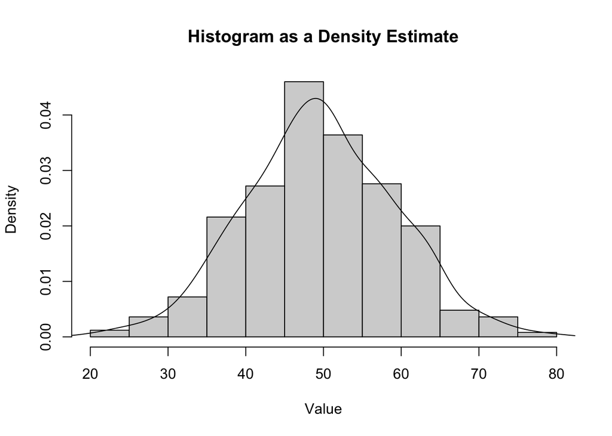

```r
data <- rnorm(500, mean = 50, sd = 10)

hist(data, probability = TRUE,
     main = "Histogram as a Density Estimate",
     xlab = "Value")
lines(density(data))
```

> **What’s happening here:** `rnorm(500, mean = 50, sd = 10)` generates 500 random numbers from a Normal distribution centred at 50. The histogram shows the shape, and `density(data)` draws a smooth curve through it. The `probability = TRUE` argument makes the y-axis show *density* instead of counts, so the histogram and density curve are on the same scale.

### Effect of sample size

What happens when we have more data? The histogram gets smoother and follows the true bell curve more closely:

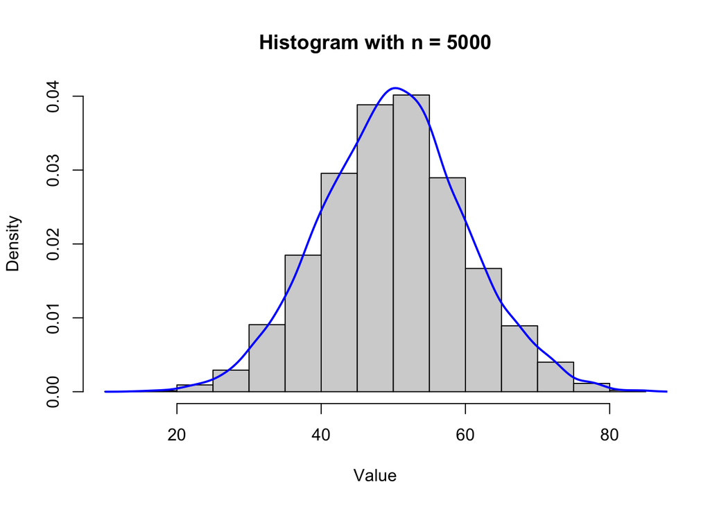

```r
# Change the sample size and observe how the histogram and density change
set.seed(7)
data_large <- rnorm(5000, mean = 50, sd = 10)
hist(data_large, probability = TRUE,
     main = "Histogram with n = 5000",
     xlab = "Value")
lines(density(data_large), col = "blue", lwd = 2)
```

```r
# With a larger sample the histogram follows the true normal density much more
# closely and the density curve is smoother.
```

### Effect of bin width

The number of bars (bins) in a histogram matters a lot:

- **Too few bins** (wide bars) — Over-smooths the data. You lose detail.
- **Too many bins** (narrow bars) — Under-smooths the data. You see noise instead of the true pattern.

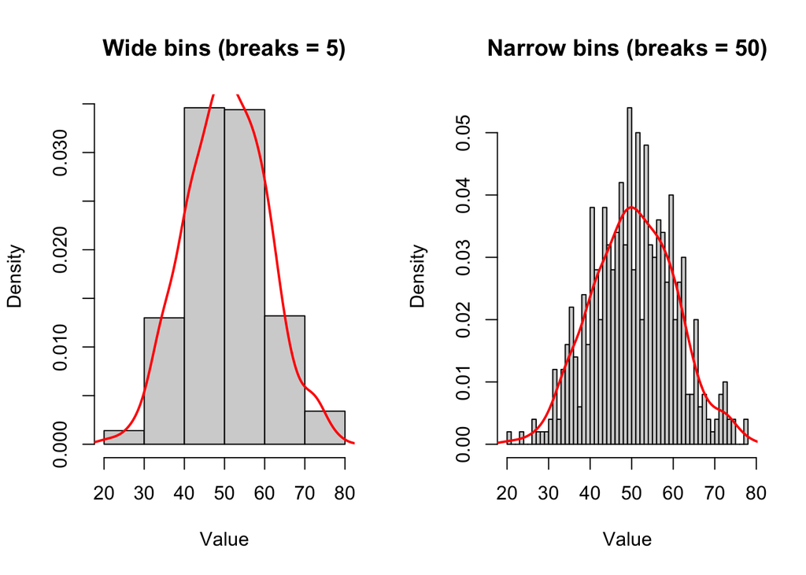

```r
# Try a different bin width and comment on the effect
set.seed(7)
data_bw <- rnorm(500, mean = 50, sd = 10)

par(mfrow = c(1, 2))

hist(data_bw, probability = TRUE, breaks = 5,
     main = "Wide bins (breaks = 5)", xlab = "Value")
lines(density(data_bw), col = "red", lwd = 2)

hist(data_bw, probability = TRUE, breaks = 50,
     main = "Narrow bins (breaks = 50)", xlab = "Value")
lines(density(data_bw), col = "red", lwd = 2)
```

```r
par(mfrow = c(1, 1))
# Wide bins over-smooth: we lose detail about the shape of the distribution.
# Narrow bins under-smooth: the histogram becomes spiky and we may be
# fitting noise rather than signal. A moderate bin width balances bias and
# variance — a theme that recurs in kernel density estimation.
```

> **Takeaway:** Choosing the right bin width is a **bias-variance trade-off** — a concept that comes up again and again in statistics. We’ll revisit this formally when we study kernel density estimation.

## 6. Lists: Storing Complex Objects

### What is a list?

A **list** is like a container that can hold **anything** — vectors, data frames, even other lists. Unlike vectors (which must contain all the same type), lists can mix numbers, text, dates, and more.

**Why do we care?** In R, almost every function that fits a model (like `lm()`, `t.test()`, etc.) returns its results as a list. So understanding lists is essential for working with statistical output.

```r
l <- list(
  numbers = x,
  summary = c(mean = mean(x), sd = sd(x)),
  metadata = list(source = "simulation", date = Sys.Date())
)

str(l)
```

```
## List of 3
##  $ numbers : Named num [1:3] 10 11 12
##   ..- attr(*, "names")= chr [1:3] "first" "second" "third"
##  $ summary : Named num [1:2] 11 1
##   ..- attr(*, "names")= chr [1:2] "mean" "sd"
##  $ metadata:List of 2
##   ..$ source: chr "simulation"
##   ..$ date  : Date[1:1], format: "2026-02-25"
```

> **`str()`** stands for “structure” — it shows you what’s inside an object. Very useful for exploring lists!

## 7. Reading and Writing Data

### Where is R looking for files?

R has a “working directory” — the folder it looks in when you ask it to open or save files. You can check the current working directory with:

```r
getwd()
```

```
## [1] "/Users/arif/Desktop/SC/personal notes/SC Labs/Week 1 Lab"
```

> **Heads up:** The working directory for your R Markdown file might be different from the one in the console below. This can cause confusion! The R Markdown file usually uses its own folder as the working directory.

### Setting up a data folder

It’s good practice to organise your files. Let’s create a subfolder for our data:

```r
dir.create("lab0data", showWarnings = FALSE)
setwd("lab0data")
```

> **Note:** You might see a warning about `setwd()`. That’s because inside R Markdown, changing the working directory only affects the current code chunk. A more reliable approach is to use the `here` package, which always gives paths relative to your project folder:

```r
library(here)
file_path <- here("lab0data", "mydata.csv")
file_path
```

```
## [1] "/Users/arif/Desktop/SC/personal notes/lab0data/mydata.csv"
```

### Reading a CSV file

CSV (Comma-Separated Values) files are the most common way to store datasets. `read.csv()` loads them into a data frame:

```r
housing <- read.csv("hp1602.csv")
str(housing)
```

```
## 'data.frame':    166 obs. of  26 variables:
##  $ X          : chr  "1975:Q1" "1975:Q2" "1975:Q3" "1975:Q4" ...
##  $ Australia  : num  7.6 7.74 8.04 8.3 8.58 8.83 9.07 9.26 9.48 9.66 ...
##  $ Belgium    : num  15.2 15.9 16.6 17.6 18.8 ...
##  $ Canada     : num  16.2 16.4 17.1 17.3 17.6 ...
##  $ Switzerland: num  48.8 48.2 47.7 47.1 46.4 ...
##  $ Germany    : num  52 52.7 53.3 54.1 54.8 ...
##  $ Denmark    : num  15.8 16.2 17 17.1 17.7 ...
##  $ Spain      : num  8.71 9.75 9.96 10.7 10.77 ...
##  $ Finland    : num  13.5 13.7 13.8 14.2 14.4 ...
##  $ France     : num  11.1 11.5 11.9 12.4 12.9 ...
##  $ UK         : num  5.92 6.03 6.15 6.25 6.46 6.58 6.66 6.81 6.94 6.99 ...
##  $ Ireland    : num  3.44 3.67 3.89 4.11 4.32 4.53 4.73 4.94 5.06 5.29 ...
##  $ Italy      : num  8.19 8.06 7.97 7.91 7.88 7.89 7.93 8 8.11 8.26 ...
##  $ Japan      : num  60.1 60.3 60.5 60.7 61 ...
##  $ S..Korea   : num  8.7 9.23 9.82 10.43 11.07 ...
##  $ Luxembourg : num  7.49 8.19 8.87 9.52 10.16 ...
##  $ Netherlands: num  14.9 15.8 16.8 18 19 ...
##  $ Norway     : num  13.4 13.5 13.7 14.1 14.1 ...
##  $ New.Zealand: num  7.41 7.43 7.54 7.71 7.85 8.02 8.12 8.24 8.41 8.61 ...
##  $ Sweden     : num  14.6 15.1 15.6 16.1 16.7 ...
##  $ US         : num  17.3 17.6 17.7 18 18.1 ...
##  $ S..Africa  : num  3.23 3.28 3.29 3.37 3.44 3.51 3.51 3.51 3.51 3.56 ...
##  $ Croatia    : num  0 0 0 0 0 0 0 0 0 0 ...
##  $ Israel     : num  0 0 0 0 0 0 0 0 0 0.01 ...
##  $ X.1        : logi  NA NA NA NA NA NA ...
##  $ Aggregate  : num  22.5 22.8 23.1 23.4 23.7 ...
```

### Saving and loading R objects

You can save any R object to a file and load it back later. This is useful for **long-running analyses** — you don’t want to re-run everything from scratch if R crashes!

- **`saveRDS()`** — saves a single R object to a file.
- **`readRDS()`** — loads it back.

```r
saveRDS(housing, "housing.rds")
housing2 <- readRDS("housing.rds")
```

### Your turn: Explore the data

```r
# Inspect the column names and basic summaries of the housing data
cat("Column names:\n")
```

```
## Column names:
```

```r
print(names(housing))
```

```
##  [1] "X"           "Australia"   "Belgium"     "Canada"      "Switzerland"
##  [6] "Germany"     "Denmark"     "Spain"       "Finland"     "France"
## [11] "UK"          "Ireland"     "Italy"       "Japan"       "S..Korea"
## [16] "Luxembourg"  "Netherlands" "Norway"      "New.Zealand" "Sweden"
## [21] "US"          "S..Africa"   "Croatia"     "Israel"      "X.1"
## [26] "Aggregate"
```

```r
cat("\nDimensions:", nrow(housing), "rows x", ncol(housing), "columns\n")
```

```
##
## Dimensions: 166 rows x 26 columns
```

```r
summary(housing)
```

```
##       X               Australia         Belgium           Canada
##  Length:166         Min.   :  7.60   Min.   : 15.18   Min.   : 16.16
##  Class :character   1st Qu.: 22.32   1st Qu.: 29.63   1st Qu.: 37.81
##  Mode  :character   Median : 45.15   Median : 56.41   Median : 61.88
##                     Mean   : 65.62   Mean   : 68.60   Mean   : 75.38
##                     3rd Qu.:102.73   3rd Qu.:107.12   3rd Qu.:105.83
##                     Max.   :188.23   Max.   :145.65   Max.   :198.06
##   Switzerland        Germany          Denmark           Spain
##  Min.   : 45.78   Min.   : 52.02   Min.   : 15.78   Min.   :  8.71
##  1st Qu.: 76.44   1st Qu.: 80.47   1st Qu.: 36.36   1st Qu.: 20.37
##  Median : 95.67   Median : 97.98   Median : 46.44   Median : 39.10
##  Mean   : 92.62   Mean   : 91.04   Mean   : 62.35   Mean   : 51.56
##  3rd Qu.:109.35   3rd Qu.:100.77   3rd Qu.:102.91   3rd Qu.: 83.84
##  Max.   :139.54   Max.   :121.97   Max.   :128.14   Max.   :119.36
##     Finland           France             UK            Ireland
##  Min.   : 13.49   Min.   : 11.10   Min.   :  5.92   Min.   :  3.44
##  1st Qu.: 36.64   1st Qu.: 31.24   1st Qu.: 18.50   1st Qu.: 13.80
##  Median : 56.34   Median : 48.61   Median : 37.32   Median : 23.07
##  Mean   : 65.25   Mean   : 62.18   Mean   : 55.21   Mean   : 44.24
##  3rd Qu.:104.16   3rd Qu.:107.36   3rd Qu.:101.01   3rd Qu.: 75.39
##  Max.   :129.84   Max.   :125.77   Max.   :135.82   Max.   :125.43
##      Italy            Japan           S..Korea        Luxembourg
##  Min.   :  7.88   Min.   : 60.14   Min.   :  8.70   Min.   :  7.49
##  1st Qu.: 25.34   1st Qu.: 84.46   1st Qu.: 53.50   1st Qu.: 19.43
##  Median : 59.57   Median :106.08   Median : 78.70   Median : 45.02
##  Mean   : 59.17   Mean   :109.72   Mean   : 78.51   Mean   : 59.56
##  3rd Qu.: 91.92   3rd Qu.:136.08   3rd Qu.:102.37   3rd Qu.:104.75
##  Max.   :115.89   Max.   :168.47   Max.   :142.95   Max.   :149.61
##   Netherlands         Norway        New.Zealand         Sweden
##  Min.   : 14.92   Min.   : 13.36   Min.   :  7.41   Min.   : 14.57
##  1st Qu.: 27.36   1st Qu.: 33.68   1st Qu.: 22.95   1st Qu.: 28.22
##  Median : 40.66   Median : 51.62   Median : 49.06   Median : 52.68
##  Mean   : 57.86   Mean   : 72.57   Mean   : 60.96   Mean   : 69.96
##  3rd Qu.: 93.08   3rd Qu.:105.77   3rd Qu.:106.69   3rd Qu.:107.67
##  Max.   :113.10   Max.   :185.94   Max.   :173.79   Max.   :182.73
##        US           S..Africa         Croatia           Israel
##  Min.   : 17.27   Min.   :  3.23   Min.   :  0.00   Min.   :  0.00
##  1st Qu.: 36.49   1st Qu.: 10.44   1st Qu.:  0.00   1st Qu.: 10.16
##  Median : 54.63   Median : 24.66   Median : 62.92   Median : 83.74
##  Mean   : 61.33   Mean   : 56.51   Mean   : 53.40   Mean   : 72.32
##  3rd Qu.: 90.36   3rd Qu.:108.64   3rd Qu.:107.66   3rd Qu.:105.41
##  Max.   :109.18   Max.   :201.37   Max.   :140.36   Max.   :211.69
##    X.1            Aggregate
##  Mode:logical   Min.   : 22.50
##  NA's:166       1st Qu.: 45.81
##                 Median : 68.09
##                 Mean   : 70.26
##                 3rd Qu.:101.83
##                 Max.   :116.25
```

## 8. Iteration and Vectorised Computation

### Two ways to repeat a calculation

In statistics, we often need to apply the same calculation to many columns, many groups, or many simulated datasets. R gives us two approaches:

1. **Loops** (`for`) — familiar from Python, but often slower in R.
2. **Vectorised functions** (`sapply`, `apply`, etc.) — R’s preferred way, usually faster and more concise.

```r
housingVar <- sapply(housing[, -(1:3)], var)
housingVar
```

```
##      Canada Switzerland     Germany     Denmark       Spain     Finland
##   2118.0741    627.6976    238.6095   1229.4841   1176.1087   1469.6247
##      France          UK     Ireland       Italy       Japan    S..Korea
##   1409.0291   1642.5234   1340.4031   1210.1021    902.5951   1326.8778
##  Luxembourg Netherlands      Norway New.Zealand      Sweden          US
##   1758.9673   1129.0646   2518.2116   2105.8361   2141.5058    807.5693
##   S..Africa     Croatia      Israel         X.1   Aggregate
##   3736.0322   2579.2723   3767.2841          NA    762.3056
```

> **What’s `housing[, -(1:3)]`?** It means “all columns *except* the first three.” The minus sign removes columns by position.

### Your turn: Loop vs sapply

Let’s compute the mean HPI (House Price Index) for each country, first with a loop, then with `sapply()`.

**The loop approach:**

- `unique()` gives you the distinct values in a column.
- `numeric(n)` creates an empty vector of length `n` to store results.
- `seq_along()` generates indices 1, 2, 3, … matching the length of the input.

```r
# Compute the mean HPI for each country using a loop (loop over the countries)
countries <- names(housing)[-(1:3)]   # country column names

mean_hpi_loop <- numeric(length(countries))
names(mean_hpi_loop) <- countries

for (i in seq_along(countries)) {
  mean_hpi_loop[i] <- mean(housing[[countries[i]]], na.rm = TRUE)
}

mean_hpi_loop
```

```
##      Canada Switzerland     Germany     Denmark       Spain     Finland
##    75.38241    92.62139    91.03747    62.35048    51.56367    65.24922
##      France          UK     Ireland       Italy       Japan    S..Korea
##    62.18181    55.20952    44.24361    59.17193   109.71500    78.50873
##  Luxembourg Netherlands      Norway New.Zealand      Sweden          US
##    59.55946    57.85506    72.56904    60.95843    69.95831    61.32663
##   S..Africa     Croatia      Israel         X.1   Aggregate
##    56.50584    53.39596    72.31886         NaN    70.25620
```

**The `sapply()` approach** (same result, one line of code!):

```r
# Repeat the computation using sapply()
mean_hpi_sapply <- sapply(housing[, -(1:3)], mean, na.rm = TRUE)
mean_hpi_sapply
```

```
##      Canada Switzerland     Germany     Denmark       Spain     Finland
##    75.38241    92.62139    91.03747    62.35048    51.56367    65.24922
##      France          UK     Ireland       Italy       Japan    S..Korea
##    62.18181    55.20952    44.24361    59.17193   109.71500    78.50873
##  Luxembourg Netherlands      Norway New.Zealand      Sweden          US
##    59.55946    57.85506    72.56904    60.95843    69.95831    61.32663
##   S..Africa     Croatia      Israel         X.1   Aggregate
##    56.50584    53.39596    72.31886         NaN    70.25620
```

```r
# Verify the two approaches give the same result
all.equal(mean_hpi_loop, mean_hpi_sapply)
```

```
## [1] TRUE
```

> **Takeaway:** `sapply()` is more concise and often faster than a loop. Use it when you want to apply the same function to every element of a list or every column of a data frame.

## 9. Split–Apply–Combine

### A powerful pattern for grouped data

Many data analysis tasks follow this three-step pattern:

1. **Split** the data into groups (e.g., by country, by treatment group).
2. **Apply** a function to each group (e.g., compute the mean).
3. **Combine** the results back together.

First, let’s reshape the housing data from **wide format** (one column per country) to **long format** (one row per country-observation pair):

```r
housing_long <- reshape(
  housing,
  varying = names(housing)[-(1:3)],
  v.names = "hpi",
  timevar = "country",
  times = names(housing)[-(1:3)],
  direction = "long"
)
```

Now we can compute the average HPI by country using `tapply()`:

```r
tapply(housing_long$hpi, housing_long$country, mean)
```

```
##   Aggregate      Canada     Croatia     Denmark     Finland      France
##    70.25620    75.38241    53.39596    62.35048    65.24922    62.18181
##     Germany     Ireland      Israel       Italy       Japan  Luxembourg
##    91.03747    44.24361    72.31886    59.17193   109.71500    59.55946
## Netherlands New.Zealand      Norway   S..Africa    S..Korea       Spain
##    57.85506    60.95843    72.56904    56.50584    78.50873    51.56367
##      Sweden Switzerland          UK          US         X.1
##    69.95831    92.62139    55.20952    61.32663          NA
```

> **How `tapply()` works:** It takes a numeric vector (`housing_long$hpi`), splits it into groups defined by a factor (`housing_long$country`), applies a function (`mean`) to each group, and returns the results.

## 10. Writing Your Own Functions

### Why write functions?

Functions let you **package up** a piece of logic so you can reuse it. Instead of copying and pasting the same code over and over, you write it once as a function and then call it whenever you need it.

**The basic structure:**

```r
my_function <- function(argument1, argument2) {
  # do something
  return(result)
}
```

Here’s a simple function that returns the mean and standard deviation of a vector:

```r
meansd <- function(x) {
  c(mean = mean(x), sd = sd(x))
}
```

Apply it across groups:

```r
tapply(housing_long$hpi, housing_long$country, meansd)
```

```
## $Aggregate
##     mean       sd
## 70.25620 27.60988
##
## $Canada
##     mean       sd
## 75.38241 46.02254
##
## $Croatia
##     mean       sd
## 53.39596 50.78654
##
## $Denmark
##     mean       sd
## 62.35048 35.06400
##
## $Finland
##     mean       sd
## 65.24922 38.33568
##
## $France
##     mean       sd
## 62.18181 37.53704
##
## $Germany
##     mean       sd
## 91.03747 15.44699
##
## $Ireland
##     mean       sd
## 44.24361 36.61152
##
## $Israel
##     mean       sd
## 72.31886 61.37821
##
## $Italy
##     mean       sd
## 59.17193 34.78652
##
```

[output cut: 36 more lines]

```
## $Switzerland
##     mean       sd
## 92.62139 25.05389
##
## $UK
##     mean       sd
## 55.20952 40.52806
##
## $US
##     mean       sd
## 61.32663 28.41776
##
## $X.1
## mean   sd
##   NA   NA
```

### Your turn: Improve the function

Let’s add the sample size (`n`) to the output, and make it handle missing values (`NA`s) gracefully:

```r
# Modify meansd() to also return the sample size
meansd <- function(x) {
  x_clean <- x[!is.na(x)]
  c(mean = mean(x_clean), sd = sd(x_clean), n = length(x_clean))
}

# Test it
meansd(c(1, 2, 3, NA, 5))
```

```
##     mean       sd        n
## 2.750000 1.707825 4.000000
```

```r
# Apply across countries
tapply(housing_long$hpi, housing_long$country, meansd)
```

```
## $Aggregate
##      mean        sd         n
##  70.25620  27.60988 166.00000
##
## $Canada
##      mean        sd         n
##  75.38241  46.02254 166.00000
##
## $Croatia
##      mean        sd         n
##  53.39596  50.78654 166.00000
##
## $Denmark
##      mean        sd         n
##  62.35048  35.06400 166.00000
##
## $Finland
##      mean        sd         n
##  65.24922  38.33568 166.00000
##
## $France
##      mean        sd         n
##  62.18181  37.53704 166.00000
##
## $Germany
##      mean        sd         n
##  91.03747  15.44699 166.00000
##
## $Ireland
##      mean        sd         n
##  44.24361  36.61152 166.00000
##
## $Israel
##      mean        sd         n
##  72.31886  61.37821 166.00000
##
## $Italy
##      mean        sd         n
##  59.17193  34.78652 166.00000
##
```

[output cut: 36 more lines]

```
## $Switzerland
##      mean        sd         n
##  92.62139  25.05389 166.00000
##
## $UK
##      mean        sd         n
##  55.20952  40.52806 166.00000
##
## $US
##      mean        sd         n
##  61.32663  28.41776 166.00000
##
## $X.1
## mean   sd    n
##  NaN   NA    0
```

> **What’s `!is.na(x)`?** It means “NOT missing”. `is.na(x)` returns `TRUE` for each `NA` value, and `!` flips it. So `x[!is.na(x)]` keeps only the non-missing values.

## 11. Simulation as a Statistical Tool

### What is simulation?

**Simulation** means generating fake data from a known model, then studying what happens. It’s one of the most powerful tools in modern statistics because it lets you answer questions like:

- “How reliable is this estimate?” (by repeating the experiment thousands of times)
- “Does my method work correctly?” (by testing it on data where you know the true answer)

### The sampling distribution of the mean

If we take a sample of 50 numbers from a Normal distribution and compute the mean, we’ll get *some* number. If we repeat this 1000 times, those 1000 means form a **sampling distribution** — it tells us how much the sample mean varies from sample to sample.

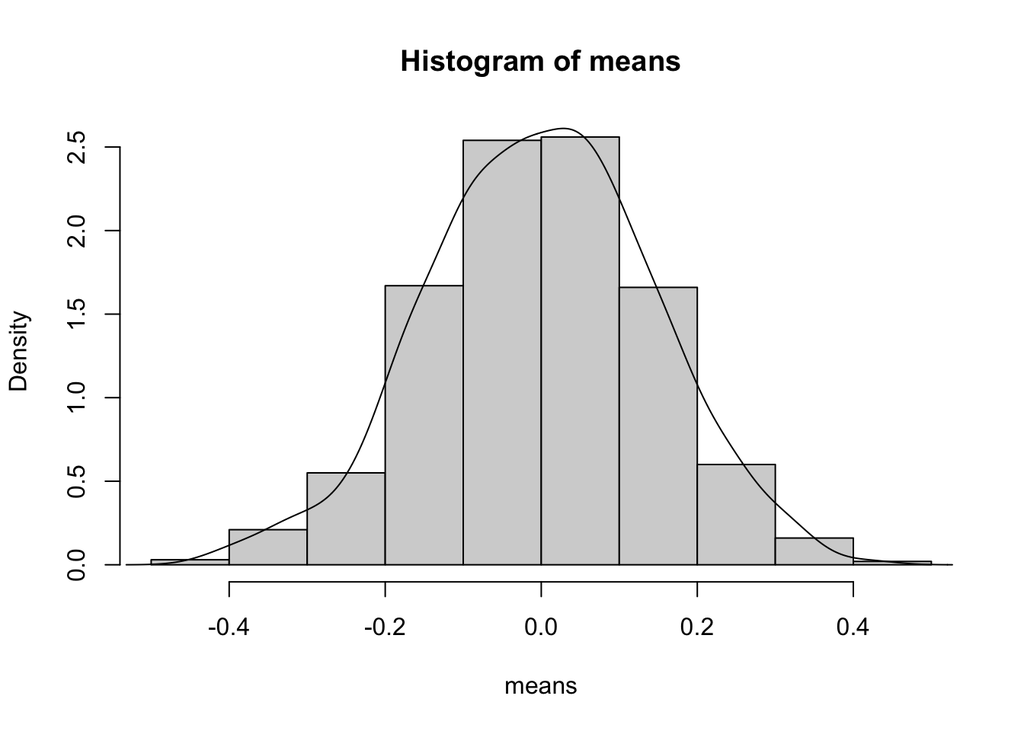

```r
simulate_mean <- function(n) mean(rnorm(n))

means <- replicate(1000, simulate_mean(50))
hist(means, probability = TRUE)
lines(density(means))
```

> **`replicate(1000, ...)`** runs the expression inside it 1000 times and collects the results. It’s like a super-compact loop.

### The Central Limit Theorem in action

What happens if we change the sample size? The **Central Limit Theorem** says that as the sample size increases, the sampling distribution of the mean becomes:

- More **concentrated** around the true mean (less spread)
- More **bell-shaped** (even if the original data isn’t normal!)

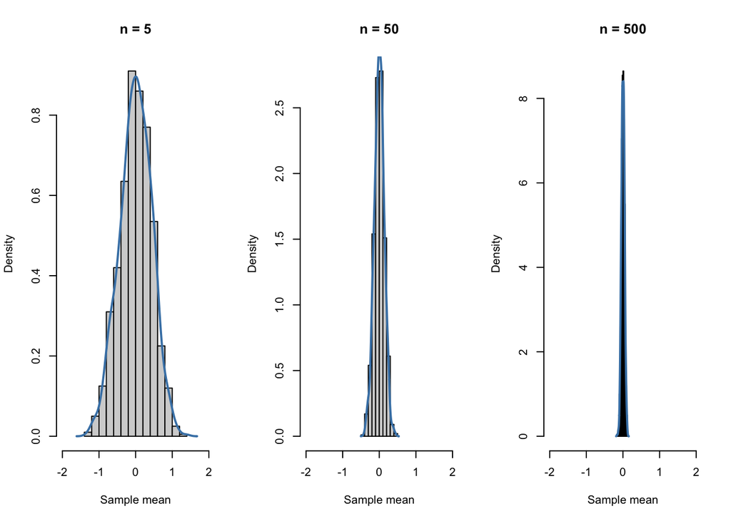

```r
# Change the sample size n and observe the effect on the sampling distribution
set.seed(123)

par(mfrow = c(1, 3))

for (n in c(5, 50, 500)) {
  sim_means <- replicate(1000, simulate_mean(n))
  hist(sim_means, probability = TRUE,
       main = paste("n =", n),
       xlab = "Sample mean",
       xlim = c(-2, 2))
  lines(density(sim_means), col = "steelblue", lwd = 2)
}
```

```r
par(mfrow = c(1, 1))
# As n increases the distribution of the sample mean becomes more
# tightly concentrated around 0 (the true mean) and more bell-shaped,
# illustrating the Central Limit Theorem in action.
```

> **What to notice:** With n = 5, the sample means are all over the place (spread from −1 to +1). With n = 500, they’re tightly clustered around 0 (the true mean). This is the CLT in action!

## Exercises

These exercises bring together all the skills from the lab. Each one builds on what you’ve learned above.

1. **Compute the correlation** between US and Canada HPI.
2. **Use simulation** (bootstrapping) to estimate how uncertain that correlation is.
3. **Write a function** that returns the minimum, median, and maximum of a numeric vector.
4. **Apply your function** to HPI values for each country.
5. **(Advanced)** Plot the distribution of simulated correlations.

```r
# Exercise 1: Correlation between US and Canada HPI
cor_us_canada <- cor(housing$US, housing$Canada, use = "complete.obs")
cat("Correlation between US and Canada HPI:", cor_us_canada, "\n")
```

```
## Correlation between US and Canada HPI: 0.9244933
```

> **What’s correlation?** It measures how strongly two variables move together. Values range from −1 (perfectly opposite) to +1 (perfectly together). A value near 0 means no linear relationship.

```r
# Exercise 2: Use simulation (bootstrap) to estimate uncertainty
set.seed(42)
n_boot <- 1000
boot_cors <- replicate(n_boot, {
  idx <- sample(nrow(housing), replace = TRUE)
  cor(housing$US[idx], housing$Canada[idx], use = "complete.obs")
})

cat("Bootstrap SE of correlation:", sd(boot_cors), "\n")
```

```
## Bootstrap SE of correlation: 0.00699358
```

```r
cat("95% CI: [", quantile(boot_cors, 0.025), ",",
    quantile(boot_cors, 0.975), "]\n")
```

```
## 95% CI: [ 0.91216 , 0.9383815 ]
```

> **What’s bootstrapping?** We resample our data *with replacement* (some rows get picked multiple times, some are left out), compute the correlation on each resampled dataset, and repeat 1000 times. The spread of those 1000 correlations tells us how uncertain our estimate is. The 95% CI means: “we’re 95% confident the true correlation falls in this range.”

```r
# Exercise 3: Function returning min, median, max
min_med_max <- function(x) {
  x_clean <- x[!is.na(x)]
  c(min    = min(x_clean),
    median = median(x_clean),
    max    = max(x_clean))
}

# Quick test
min_med_max(c(3, 1, 4, 1, 5, 9, 2, 6))
```

```
##    min median    max
##    1.0    3.5    9.0
```

```r
# Exercise 4: Apply to HPI values for each country
tapply(housing_long$hpi, housing_long$country, min_med_max)
```

```
## $Aggregate
##     min  median     max
##  22.500  68.095 116.250
##
## $Canada
##     min  median     max
##  16.160  61.875 198.060
##
## $Croatia
##     min  median     max
##   0.000  62.925 140.360
##
## $Denmark
##     min  median     max
##  15.780  46.435 128.140
##
## $Finland
##     min  median     max
##  13.490  56.345 129.840
##
## $France
##    min median    max
##  11.10  48.61 125.77
##
## $Germany
##     min  median     max
##  52.020  97.985 121.970
##
## $Ireland
##     min  median     max
##   3.440  23.075 125.430
##
## $Israel
##    min median    max
##   0.00  83.74 211.69
##
## $Italy
##    min median    max
##   7.88  59.57 115.89
##
```

[output cut: 36 more lines]

```
## $Switzerland
##     min  median     max
##  45.780  95.675 139.540
##
## $UK
##    min median    max
##   5.92  37.32 135.82
##
## $US
##     min  median     max
##  17.270  54.635 109.180
##
## $X.1
##    min median    max
##    Inf     NA   -Inf
```

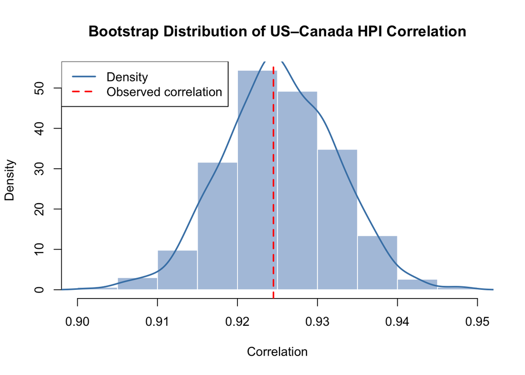

```r
# Exercise 5 (Advanced): Plot the distribution of simulated correlations
hist(boot_cors, probability = TRUE,
     main = "Bootstrap Distribution of US–Canada HPI Correlation",
     xlab = "Correlation",
     col  = "lightsteelblue",
     border = "white")
lines(density(boot_cors), col = "steelblue", lwd = 2)
abline(v = cor_us_canada, col = "red", lwd = 2, lty = 2)
legend("topleft",
       legend = c("Density", "Observed correlation"),
       col    = c("steelblue", "red"),
       lty    = c(1, 2), lwd = 2)
```

## Summary

By the end of this lab you should feel comfortable with:

- ✅ **Vectors and data frames** — R’s core data structures
- ✅ **Indexing and logical filtering** — extracting and subsetting data
- ✅ **Probability in R** — computing P(A), P(A|B), and checking independence
- ✅ **Visualisation** — histograms, density plots, and the bias-variance trade-off in bin width
- ✅ **Writing functions** — packaging up reusable logic
- ✅ **Loops vs sapply** — two ways to repeat computations
- ✅ **Simulation** — generating data to study statistical properties (like the CLT)

These skills form the **foundation** for everything else in this module. You’ll use them in every single future lab! 🚀